# R Notebook

```r
library(CodeClanData)
library(tidyverse)
library(lubridate)
```

#4 MVP ##4.1 Part 1

| product | year | revenue |
| --- | --- | --- |
| Trackers | 2019 | 8994 |
| Smart Watches | 2019 | 12003 |
| Accessories | 2019 | 5250 |
| Subscription Services | 2019 | 3750 |
| Trackers | 2018 | 8004 |
| Smart Watches | 2018 | 11000 |
| Accessories | 2018 | 4250 |
| Subscription Services | 2018 | 1005 |

###Take the data in the dataset qb_revenue_breakdown and make a stacked bar chart showing the sources of revenue across the two years in the dataset.

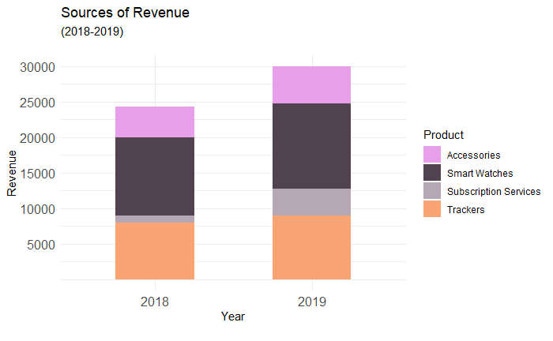

```r
qb_revenue_breakdown %>%
  janitor::clean_names() %>%
  ggplot()+
  aes(x = year, y = revenue, fill = product)+
  geom_col(width = 0.5)+
  labs(
    x = "Year\n",
    y = "Revenue",
    title = "Sources of Revenue",
    subtitle = "(2018-2019)\n",
    fill = "Product"
  ) +
  scale_y_continuous(breaks = c(5000,10000,15000,20000,25000,30000))+
  scale_fill_manual(values =col_scheme)+
  theme_minimal()+
  theme(axis.text = element_text(size = 12))
```

###Make a line chart showing monthly sales of the “flagship product” - the ‘KwikBit Unit 1’ - over the last year. This data is inside qb_monthly_sales, but you will need to use filter() or subset() (base R).

| date | cashflow | amount |
| --- | --- | --- |
| 2019-07-01 | Kwikbit Unit 1 Sales | 601.74 |
| 2019-06-01 | Kwikbit Unit 1 Sales | 567.89 |
| 2019-05-01 | Kwikbit Unit 1 Sales | 536.00 |
| 2019-04-01 | Kwikbit Unit 1 Sales | 550.78 |
| 2019-03-01 | Kwikbit Unit 1 Sales | 526.03 |
| 2019-02-01 | Kwikbit Unit 1 Sales | 584.22 |
| 2019-01-01 | Kwikbit Unit 1 Sales | 530.76 |
| 2018-12-01 | Kwikbit Unit 1 Sales | 504.80 |
| 2018-11-01 | Kwikbit Unit 1 Sales | 513.67 |
| 2018-10-01 | Kwikbit Unit 1 Sales | 499.99 |

[output cut: 2 more lines]

```
Ignoring unknown parameters: width
```

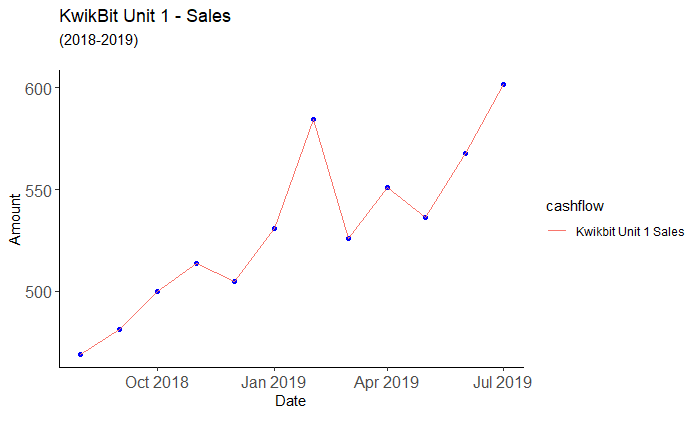

```r
qb_monthly_sales %>%
  janitor::clean_names() %>%
    filter(cashflow == "Kwikbit Unit 1 Sales" ) %>%
  #filter(date >= "2019-01-01" & date <= "2019-12-31") %>%
  ggplot()+
  aes(x = date, y = amount, colour = cashflow)+
  geom_point(width = 0.5, colour = "blue")+
  geom_line()+
   labs(
    x = "Date\n",
    y = "Amount",
    title = "KwikBit Unit 1 - Sales",
    subtitle = "(2018-2019)\n",
    fill = "Cashflow"
  )+
 # scale_x_discrete(labels = c("Aug18", "Sep18", "Oct18", "Nov18", "Dec18", "Jan19", "Feb19","Mar19","April19", "May19", "June19", "July19"))+
 # scale_fill_manual(values = col_scheme)+
  theme_classic()+
  theme(axis.text = element_text(size = 12))
```

###Make a line chart showing monthly revenue and costs over the last year. This data is also in qb_monthly_sales.

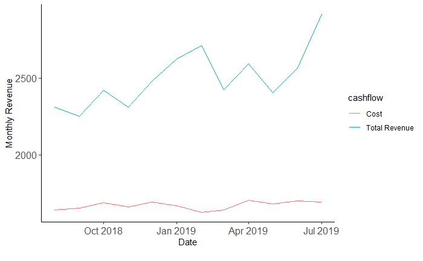

```r
qb_monthly_sales %>%
  janitor::clean_names() %>%
  filter(cashflow %in% c("Total Revenue", "Cost")) %>%
  group_by(date, cashflow) %>%
  summarise(monthly_revenue = sum(amount)) %>%
  ggplot()+
  aes(x = date, y = monthly_revenue, colour = cashflow)+
  geom_line()+
  labs(
    x = "Date\n",
    y = "Monthly Revenue",
    fill = "Cashflow"
  )+
 # scale_x_discrete(labels = c("Aug18", "Sep18", "Oct18", "Nov18", "Dec18", "Jan19", "Feb19","Mar19","April19", "May19", "June19", "July19"))+
 # scale_fill_manual(values = col_scheme)+
  theme_classic()+
  theme(axis.text = element_text(size = 12))
```

###Show annual sales of personal fitness trackers over the last 5 years broken down by company as a ribbon plot (use geom_area). This data is in qb_competitors.

| Company | Year | Revenue |
| --- | --- | --- |
| Competitor 1 | 2019 | 2216000 |
| Competitor 2 | 2019 | 1760000 |
| Competitor 3 | 2019 | 1455000 |
| Competitor 4 | 2019 | 1229000 |
| Competitor 1 | 2018 | 2144400 |
| Competitor 2 | 2018 | 1440000 |
| Competitor 3 | 2018 | 1555000 |
| Competitor 4 | 2018 | 987000 |
| Competitor 1 | 2017 | 1750000 |
| Competitor 2 | 2017 | 987000 |

[output cut: 10 more lines]

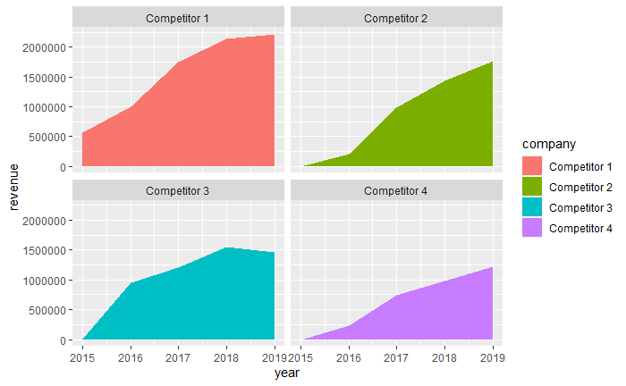

```r
qb_competitors %>%
  janitor::clean_names() %>%
  ggplot()+
  aes(x = year, y = revenue, fill = company)+
  geom_area()+
  facet_wrap(~company)
```

###Now show the sales from the four competitors as a line graph. Include an extra layer that shows the data points used to make the lines.

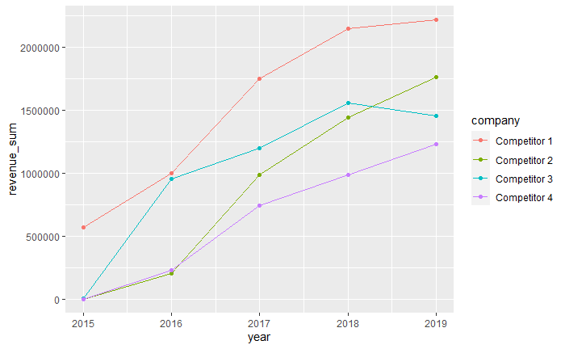

```r
qb_competitors %>%
  janitor::clean_names() %>%
  group_by(company,year) %>%
  summarise(revenue_sum = sum(revenue)) %>%
  ggplot()+
  aes(x = year, y = revenue_sum, colour = company )+
  geom_line(stat = "identity")+
  geom_point()
```

###Now the company wants to compare the number of steps that their device counts vs. their competitors. Make a line graph of the number of steps throughout time, and use faceting to compare between companies and people. The data for this is in qb_device_data.

|  | device | id | hours | mins | counts |
| --- | --- | --- | --- | --- | --- |
| 361 | qikbit1 | person1 | 6 | 0 | 0 |
| 362 | qikbit1 | person1 | 6 | 1 | 0 |
| 363 | qikbit1 | person1 | 6 | 2 | 0 |
| 364 | qikbit1 | person1 | 6 | 3 | 0 |
| 365 | qikbit1 | person1 | 6 | 4 | 0 |
| 366 | qikbit1 | person1 | 6 | 5 | 0 |
| 367 | qikbit1 | person1 | 6 | 6 | 0 |
| 368 | qikbit1 | person1 | 6 | 7 | 0 |
| 369 | qikbit1 | person1 | 6 | 8 | 0 |
| 370 | qikbit1 | person1 | 6 | 9 | 0 |

[output cut: 990 more lines]

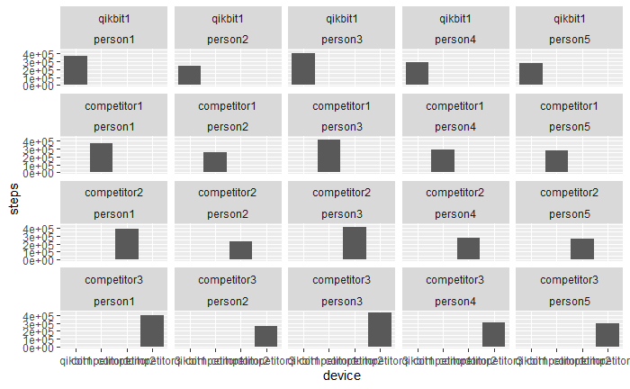

```r
qb_device_data %>%
 group_by(device, id) %>%
 summarise(steps = sum(counts)) %>%
ggplot()+
 aes(x = device, y = steps)+
 geom_bar(stat = "identity")+
facet_wrap(~device ~id)
```

[figure not shown]

[figure not shown]

```r
qb_device_data %>%
  unite("time", hours:mins, sep = ".") %>%
  ggplot() +
  aes(x = time ,y = counts)+
    geom_line()
```

```r
qb_device_data %>%
  mutate(time = (hours* 60) + mins) %>%
  ggplot ()+
  aes(x = time, y = counts)+
  geom_line()+
  facet_grid(~device ~id)
```